# Global warming through data - an artistic approach

Filippo Pilutti

2026-11-20

## Setup, import, data exploration

```r
library(tidyverse)

# Download data
co2_raw <- read_csv(
  "https://raw.githubusercontent.com/owid/co2-data/master/owid-co2-data.csv")

# Save data locally
write_csv(co2_raw, "data/owid.csv")
```

```r
co2_raw <- read_csv("data/owid.csv")

# First data exploration
glimpse(co2_raw)
```

```
## Rows: 56,269
## Columns: 79
## $ country                                   <chr> "Afghanistan", "Afghanistan"…
## $ year                                      <dbl> 1750, 1751, 1752, 1753, 1754…
## $ iso_code                                  <chr> "AFG", "AFG", "AFG", "AFG", …
## $ population                                <dbl> 2802560, NA, NA, NA, NA, NA,…
## $ gdp                                       <dbl> NA, NA, NA, NA, NA, NA, NA, …
## $ cement_co2                                <dbl> 0, 0, 0, 0, 0, 0, 0, 0, 0, 0…
## $ cement_co2_per_capita                     <dbl> 0, NA, NA, NA, NA, NA, NA, N…
## $ co2                                       <dbl> NA, NA, NA, NA, NA, NA, NA, …
## $ co2_growth_abs                            <dbl> NA, NA, NA, NA, NA, NA, NA, …
## $ co2_growth_prct                           <dbl> NA, NA, NA, NA, NA, NA, NA, …
## $ co2_including_luc                         <dbl> NA, NA, NA, NA, NA, NA, NA, …
## $ co2_including_luc_growth_abs              <dbl> NA, NA, NA, NA, NA, NA, NA, …
## $ co2_including_luc_growth_prct             <dbl> NA, NA, NA, NA, NA, NA, NA, …
```

[output cut: 66 more lines]

```r
# Year ranges
range(co2_raw$year)
```

```
## [1] 1750 2025
```

```r
# Number of distinct entries for country
n_distinct(co2_raw$country)
```

```
## [1] 259
```

```r
# Lines without ISO represent aggregates
co2_raw |>
  filter(is.na(iso_code)) |>
  distinct(country) |>
  print(n = Inf)
```

```
## # A tibble: 36 × 1
##    country
##    <chr>
##  1 Africa
##  2 Africa (GCP)
##  3 Asia
##  4 Asia (GCP)
##  5 Asia (excl. China and India)
##  6 Central America (GCP)
##  7 Europe
##  8 Europe (GCP)
##  9 Europe (excl. EU-27)
## 10 Europe (excl. EU-28)
## 11 European Union (27)
## 12 European Union (28)
```

[output cut: 24 more lines]

We notice that we have some aggregates for the countries, such as `World`, `Africa`, `Asia`, …

We should get rid of them, otherwise we will consider the data many times for each country. We also notice that Kosovo does not have an ISO code, so we should not discard it with the other aggregates.

Let’s build two data frames, one keeping only the countries with a valid ISO code, plus Kosovo, which does not have an official ISO code, the other with the total global data. We will only keep the variables we need for our analysis.

```r
co2_countries <- co2_raw |>
  filter(!is.na(iso_code) | country == "Kosovo") |>
  select(country, iso_code, year, population, gdp, co2, co2_per_capita,
         cumulative_co2, coal_co2, oil_co2, gas_co2)
n_distinct(co2_countries$country)
```

```
## [1] 224
```

```r
glimpse(co2_countries)
```

```
## Rows: 48,481
## Columns: 11
## $ country        <chr> "Afghanistan", "Afghanistan", "Afghanistan", "Afghanist…
## $ iso_code       <chr> "AFG", "AFG", "AFG", "AFG", "AFG", "AFG", "AFG", "AFG",…
## $ year           <dbl> 1750, 1751, 1752, 1753, 1754, 1755, 1756, 1757, 1758, 1…
## $ population     <dbl> 2802560, NA, NA, NA, NA, NA, NA, NA, NA, NA, 2866255, N…
## $ gdp            <dbl> NA, NA, NA, NA, NA, NA, NA, NA, NA, NA, NA, NA, NA, NA,…
## $ co2            <dbl> NA, NA, NA, NA, NA, NA, NA, NA, NA, NA, NA, NA, NA, NA,…
## $ co2_per_capita <dbl> NA, NA, NA, NA, NA, NA, NA, NA, NA, NA, NA, NA, NA, NA,…
## $ cumulative_co2 <dbl> NA, NA, NA, NA, NA, NA, NA, NA, NA, NA, NA, NA, NA, NA,…
## $ coal_co2       <dbl> NA, NA, NA, NA, NA, NA, NA, NA, NA, NA, NA, NA, NA, NA,…
## $ oil_co2        <dbl> NA, NA, NA, NA, NA, NA, NA, NA, NA, NA, NA, NA, NA, NA,…
## $ gas_co2        <dbl> NA, NA, NA, NA, NA, NA, NA, NA, NA, NA, NA, NA, NA, NA,…
```

```r
co2_world <- co2_raw |>
  filter(country == "World") |>
  select(year, population, co2, co2_per_capita, cumulative_co2, coal_co2,
         oil_co2, gas_co2)
co2_world
```

```
## # A tibble: 276 × 8
##     year population   co2 co2_per_capita cumulative_co2 coal_co2 oil_co2 gas_co2
##    <dbl>      <dbl> <dbl>          <dbl>          <dbl>    <dbl>   <dbl>   <dbl>
##  1  1750  753279296  9.31          0.012           9.31     9.31      NA      NA
##  2  1751         NA  9.41         NA              18.7      9.41      NA      NA
##  3  1752         NA  9.51         NA              28.2      9.51      NA      NA
##  4  1753         NA  9.61         NA              37.8      9.61      NA      NA
##  5  1754         NA  9.73         NA              47.6      9.73      NA      NA
##  6  1755         NA  9.79         NA              57.4      9.79      NA      NA
##  7  1756         NA  9.91         NA              67.3      9.91      NA      NA
##  8  1757         NA 10.1          NA              77.4     10.1       NA      NA
##  9  1758         NA 10.2          NA              87.6     10.2       NA      NA
## 10  1759         NA 10.3          NA              97.9     10.3       NA      NA
## # ℹ 266 more rows
```

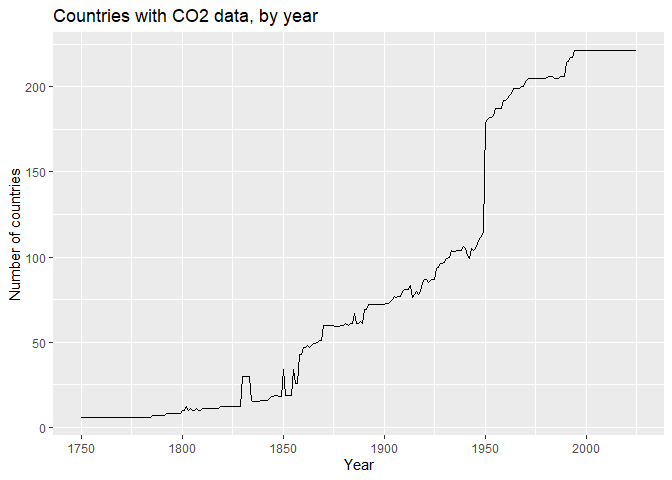

```r
# Number of countries with a non-missing co2 value, per year
coverage <- co2_countries |>
  filter(!is.na(co2)) |>
  count(year, name = "n_countries")

ggplot(coverage, aes(x = year, y = n_countries)) +
  geom_line() +
  labs(title = "Countries with CO2 data, by year",
       x = "Year", y = "Number of countries")
```

## Data visualization and analysis

### Global trend

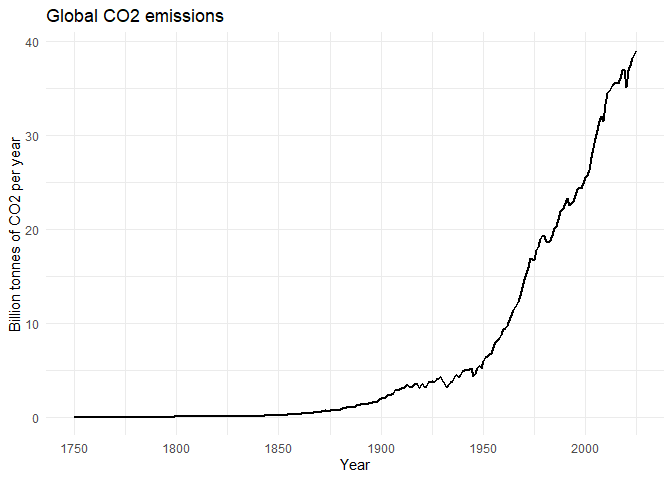

```r
# Visualize the trend of global co2 emissions
world_plot <- co2_world |>
  # Convert co2 from millions to billions of tonnes
  ggplot(aes(x = year, y = co2 / 1000)) +
  geom_line(linewidth = 0.8) +
  labs(title = "Global CO2 emissions", x = "Year",
       y = "Billion tonnes of CO2 per year") +
  theme_minimal()
world_plot
```

We can see a clear positively increasing trend. We notice that in some years there have been decreases in the emissions. Let’s try to find in which years, and what could have caused them.

```r
# Years with the largest drops in global emissions in percentage
co2_world |>
  # Change with respect to the previous year
  mutate(change_pct = (co2 - lag(co2)) / lag(co2) * 100) |>
  filter(year >= 1900) |>
  arrange(change_pct) |>
  select(year, co2, change_pct) |>
  head(8)
```

```
## # A tibble: 8 × 3
##    year   co2 change_pct
##   <dbl> <dbl>      <dbl>
## 1  1945 4295.     -16.9
## 2  1919 3045.     -13.2
## 3  1921 3121.     -12.1
## 4  1931 3543.     -10.6
## 5  1932 3196.      -9.81
## 6  1914 3204.      -9.32
## 7  1930 3964.      -7.67
## 8  1938 4239.      -5.85
```

```r
# Years with the largest absolute drops in global emissions
co2_world |>
  mutate(change = co2 - lag(co2)) |> # Change with respect to the previous year
  filter(year >= 1900) |>
  arrange(change) |>
  select(year, co2, change) |>
  head(8)
```

```
## # A tibble: 8 × 3
##    year    co2 change
##   <dbl>  <dbl>  <dbl>
## 1  2020 35095. -1965.
## 2  1945  4295.  -875.
## 3  1992 22547.  -692.
## 4  2009 31508.  -541.
## 5  1981 18731.  -498.
## 6  1919  3045.  -464.
## 7  1921  3121.  -431.
## 8  1931  3543.  -421.
```

We notice some interesting years:

- **1914**: First World War
- **1919 - 1921**: Post-war recession after World War 1
- **1930 - 1932**: Great Depression
- **1945**: End of World War 2
- **1981**: Oil crisis
- **1992**: USSR collapse
- **2009**: Financial crisis
- **2020**: COVID-19 pandemic

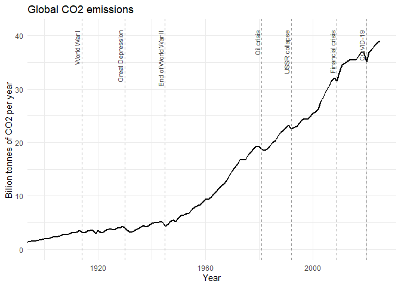

```r
# Historical events
events <- tibble(
  year = c(1914, 1930, 1945, 1981, 1992, 2009, 2020),
  label = c("World War I", "Great Depression", "End of World War II",
            "Oil crisis", "USSR collapse", "Financial crisis", "COVID-19")
)

# Visualize world events on the global trend plot
world_plot <- world_plot +
  coord_cartesian(xlim = c(1900, NA)) +
  geom_vline(data = events, aes(xintercept = year),
             linetype = "dashed", color = "grey60") +
  geom_text(data = events, aes(x = year, y = 41, label = label),
            angle = 90, hjust = 1, vjust = -0.4, size = 3, color = "grey30")
world_plot
```

Two key observations emerge from the historical trend of global CO2 emissions:

- Following each decline, emissions have resumed their upward trajectory relatively quickly.
- Historically, major reductions in global CO2 emissions have coincided primarily with economic crises and wars, rather than climate policies or deliberate environmental action.

### Cumulative global emissions

```r
# Cumulative CO2 emissions released before/after a given year
co2_world |>
  mutate(share = cumulative_co2 / last(cumulative_co2)) |>
  filter(year %in% c(1900, 1950, 1990, 2000, 2010, 2020)) |>
  transmute(
    year,
    emitted_before = scales::percent(share),
    emitted_after = scales::percent(1 - share)
  )
```

```
## # A tibble: 6 × 3
##    year emitted_before emitted_after
##   <dbl> <chr>          <chr>
## 1  1900 2.4%           97.6%
## 2  1950 12.3%          87.7%
## 3  1990 42.7%          57.3%
## 4  2000 55.3%          44.7%
## 5  2010 71.0%          29.0%
## 6  2020 89.9%          10.1%
```

```r
# Total emissions per 25-year period, with all years up to 1900 in one group
last_year  <- max(co2_world$year)
period_len <- 25
first_year <- min(co2_world$year)
cutoff     <- 1900

periods <- co2_world |>
  mutate(end = last_year - (last_year - year) %/% period_len * period_len,
         period = if_else(year <= cutoff,
                          paste0(first_year, "-", cutoff),
                          paste0(end - period_len + 1, "-", end))) |>
  group_by(period) |>
  summarise(emissions = sum(co2)) |>
  mutate(share = emissions / sum(emissions))

periods
```

```
## # A tibble: 6 × 3
##   period    emissions  share
##   <chr>         <dbl>  <dbl>
## 1 1750-1900    45140. 0.0239
## 2 1901-1925    76272. 0.0404
## 3 1926-1950   110856. 0.0588
## 4 1951-1975   275499. 0.146
## 5 1976-2000   535846. 0.284
## 6 2001-2025   843220. 0.447
```

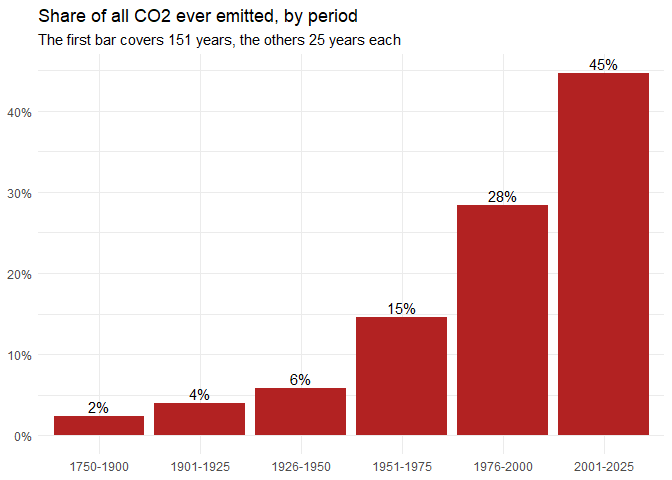

```r
ggplot(periods, aes(x = period, y = share)) +
  geom_col(fill = "firebrick") +
  geom_text(aes(label = scales::percent(share, accuracy = 1)), vjust = -0.3) +
  scale_y_continuous(labels = scales::percent) +
  labs(title = "Share of all CO2 ever emitted, by period",
       subtitle = "The first bar covers 151 years, the others 25 years each",
       x = NULL, y = NULL) +
  theme_minimal()
```

### Countries with the most CO2 emissions

We want to check which countries had the most emissions in the last year, and which ones have emitted the most CO2 cumulatively.

```r
# World total for last year
world_latest <- co2_world |>
  filter(year == last_year)

# Annual and cumulative emissions for each country, as share of the world total
countries_latest <- co2_countries |>
  filter(year == last_year) |>
  mutate(
    share_annual = co2 / world_latest$co2,
    share_cumulative = cumulative_co2 / world_latest$cumulative_co2)
```

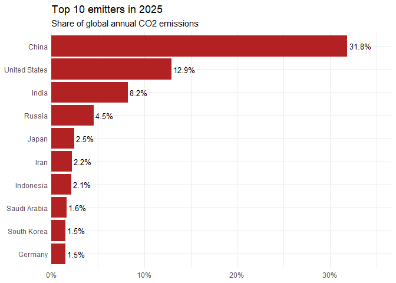

```r
# Visualize the top 10 emitters for the last year
top_annual <- countries_latest |>
  slice_max(co2, n = 10)

top_annual |>
  ggplot(aes(x = share_annual, y = fct_reorder(country, share_annual))) +
  geom_col(fill = "firebrick") +
  geom_text(aes(label = scales::percent(share_annual, accuracy = 0.1)),
            hjust = -0.1, size = 3.5) +
  scale_x_continuous(labels = scales::percent,
                     expand = expansion(mult = c(0,0.15))) +
  labs(title = paste("Top 10 emitters in", last_year),
       subtitle = "Share of global annual CO2 emissions",
       x = NULL, y = NULL) +
  theme_minimal()
```

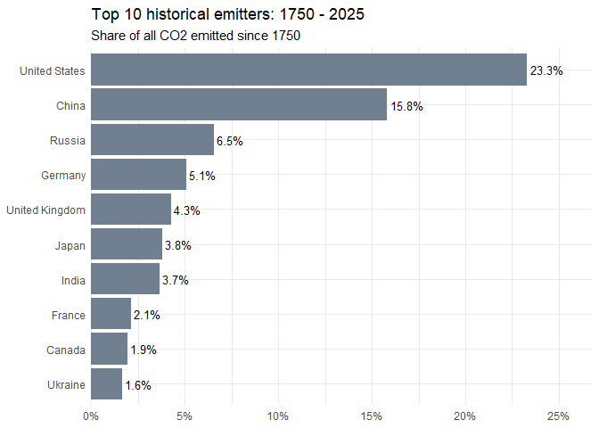

```r
# Visualize the top 10 cumulative emitters
top_cumulative <- countries_latest |>
  slice_max(cumulative_co2, n = 10)

top_cumulative |>
  ggplot(aes(x = share_cumulative,
             y = fct_reorder(country, share_cumulative))) +
  geom_col(fill = "slategrey") +
  geom_text(aes(label = scales::percent(share_cumulative, accuracy = 0.1)),
            hjust = -0.1, size = 3.5) +
  scale_x_continuous(labels = scales::percent,
                     expand = expansion(mult = c(0, 0.15))) +
  labs(title = paste(paste("Top 10 historical emitters:", first_year), paste("-"), last_year),
       subtitle = paste("Share of all CO2 emitted since", first_year),
       x = NULL, y = NULL) +
  theme_minimal()
```

```r
# Comparison of the two rankings
countries_latest |>
  mutate(
    rank_annual = min_rank(desc(co2)),
    rank_cumulative = min_rank(desc(cumulative_co2))) |>
  filter(rank_annual <= 10 | rank_cumulative <= 10) |>
  arrange(rank_cumulative) |>
  transmute(country, rank_cumulative, rank_annual,
            share_cumulative = scales::percent(share_cumulative, accuracy = 0.1),
            share_annual = scales::percent(share_annual, accuracy = 0.1))
```

```
## # A tibble: 14 × 5
##    country        rank_cumulative rank_annual share_cumulative share_annual
##    <chr>                    <int>       <int> <chr>            <chr>
##  1 United States                1           2 23.3%            12.9%
##  2 China                        2           1 15.8%            31.8%
##  3 Russia                       3           4 6.5%             4.5%
##  4 Germany                      4          10 5.1%             1.5%
##  5 United Kingdom               5          18 4.3%             0.8%
##  6 Japan                        6           5 3.8%             2.5%
##  7 India                        7           3 3.7%             8.2%
##  8 France                       8          24 2.1%             0.7%
##  9 Canada                       9          11 1.9%             1.4%
## 10 Ukraine                     10          35 1.6%             0.4%
## 11 Iran                        14           6 1.2%             2.2%
## 12 South Korea                 16           9 1.1%             1.5%
## 13 Saudi Arabia                19           8 1.0%             1.6%
## 14 Indonesia                   20           7 1.0%             2.1%
```

Global emissions are highly concentrated: in both rankings, the ten largest emitters account for roughly 69% of the total. The two rankings, however, tell different stories. China is by far the largest emitter today, with almost a third of global annual emissions, but the United States remains the largest historical emitter, having released about 50% more CO₂ than China since 1750. Several early industrialised countries, such as the United Kingdom, France, Canada and Ukraine, belong to the historical top ten but not to the current one; the United Kingdom, the birthplace of the industrial revolution, ranks fifth historically yet accounts for less than 1% of today’s emissions. Conversely, recently industrialised economies and oil producers such as Iran, Indonesia, Saudi Arabia and South Korea appear only in the annual ranking. Since CO₂ persists in the atmosphere for centuries, warming depends on cumulative rather than annual emissions. This makes the question of historical responsibility central to climate negotiations.

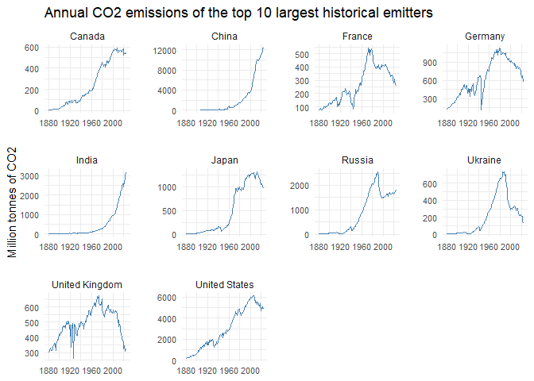

```r
# Yearly emissions of top 10 cumulative emitters
ggplot(filter(co2_countries, country %in% top_cumulative$country, year >= 1880),
       aes(x = year, y = co2)) +
  geom_line(size = 0.7, color = "steelblue") +
  facet_wrap(~ country, ncol = 4, scales = "free_y", axes = "all_x") +
  labs(title = "Annual CO2 emissions of the top 10 largest historical emitters",
       x = NULL, y = "Million tonnes of CO2") +
  theme_minimal() +
  theme(
    panel.spacing = unit(1.5, "lines"),
    axis.text.x = element_text(size = 8),
    axis.text.y = element_text(size = 8),
    strip.text = element_text(size = 9)
  )
```

For most of the twentieth century the United States was by far the largest emitter, peaking around 2005 and declining since, while early industrialised European countries have been slowly decreasing since the 1970s. After 2000 China’s emissions grew explosively, reaching more than twice those of the United States, and India is now the third largest emitter and still rising, and they both are on a growing trajectory.

### Per capita emissions

Let’s extract and visualize per capita emissions.

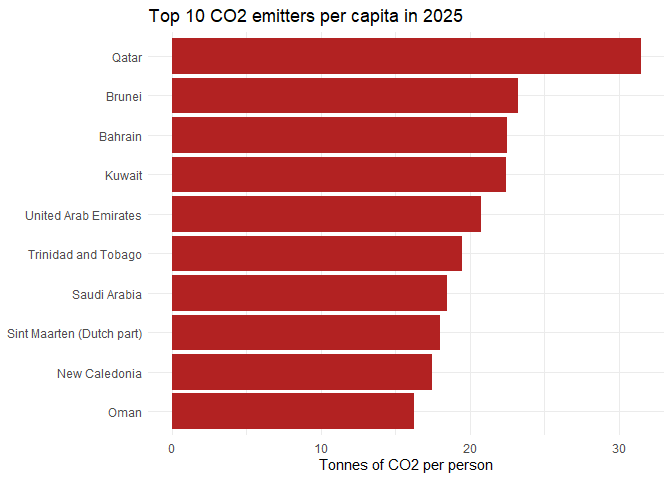

```r
# Per capita emissions plot for last year
ggplot(slice_max(countries_latest, co2_per_capita, n = 10),
       aes(x = co2_per_capita, y = fct_reorder(country, co2_per_capita))) +
  geom_col(fill = "firebrick") +
  labs(title = paste("Top 10 CO2 emitters per capita in", last_year),
       x = "Tonnes of CO2 per person", y = NULL) +
  theme_minimal()
```

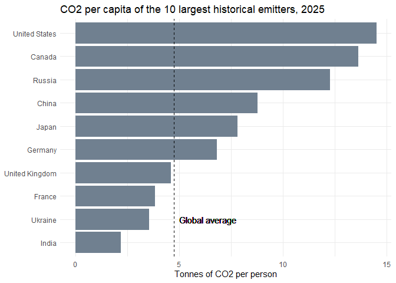

```r
# Per capita emissions of top 10 cumulative emitters
ggplot(filter(countries_latest, country %in% top_cumulative$country),
       aes(x = co2_per_capita, y = fct_reorder(country, co2_per_capita))) +
  geom_col(fill = "slategrey") +
  geom_vline(xintercept = world_latest$co2_per_capita,
             linetype = "dashed") +
  geom_text(aes(x = world_latest$co2_per_capita, y = 2, hjust = -0.1,
                label = "Global average")) +
  labs(
    title =
      paste("CO2 per capita of the 10 largest historical emitters,", last_year),
    x = "Tonnes of CO2 per person", y = NULL) +
  theme_minimal()
```

### Fuels emission in detail

Let’s see how the different fuels emissions have changed in history.

```r
# Build a table to visualize different fuels emissions
fuels <- co2_world |>
  pivot_longer(cols = c(coal_co2, oil_co2, gas_co2),
               names_to = "fuel",
               values_to = "emissions") |>
  mutate(fuel = str_remove(fuel, "_co2"))
glimpse(fuels)
```

```
## Rows: 828
## Columns: 7
## $ year           <dbl> 1750, 1750, 1750, 1751, 1751, 1751, 1752, 1752, 1752, 1…
## $ population     <dbl> 753279296, 753279296, 753279296, NA, NA, NA, NA, NA, NA…
## $ co2            <dbl> 9.306, 9.306, 9.306, 9.407, 9.407, 9.407, 9.505, 9.505,…
## $ co2_per_capita <dbl> 0.012, 0.012, 0.012, NA, NA, NA, NA, NA, NA, NA, NA, NA…
## $ cumulative_co2 <dbl> 9.306, 9.306, 9.306, 18.713, 18.713, 18.713, 28.218, 28…
## $ fuel           <chr> "coal", "oil", "gas", "coal", "oil", "gas", "coal", "oi…
## $ emissions      <dbl> 9.306, NA, NA, 9.407, NA, NA, 9.505, NA, NA, 9.610, NA,…
```

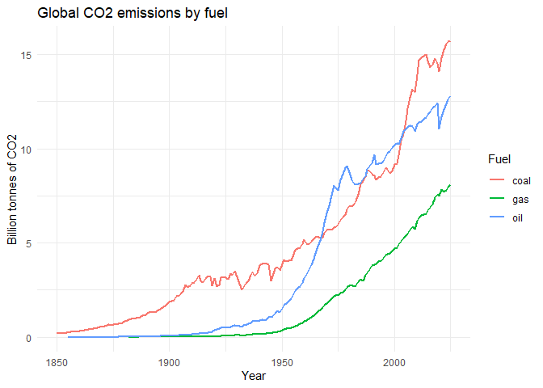

```r
# Visualize different fuel emissions by year
ggplot(filter(fuels, year >= 1850),
       aes(x = year, y = emissions / 1000, colour = fuel)) +
  geom_line(linewidth = 0.8) +
  labs(title = "Global CO2 emissions by fuel",
       x = "Year", y = "Billion tonnes of CO2", colour = "Fuel") +
  theme_minimal()
```

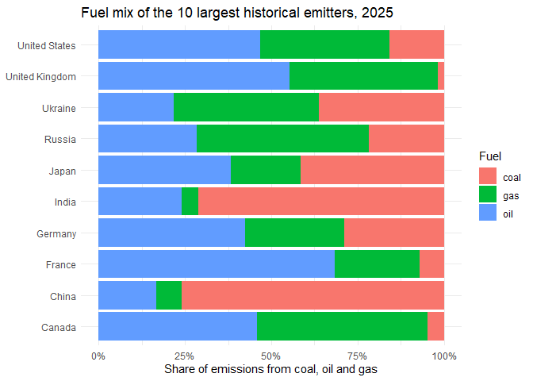

```r
fuels_top <- countries_latest |>
  filter(country %in% top_cumulative$country) |>
  pivot_longer(cols = c(coal_co2, oil_co2, gas_co2),
               names_to = "fuel",
               values_to = "emissions") |>
  mutate(fuel = str_remove(fuel, "_co2"))

ggplot(fuels_top, aes(x = emissions, y = country, fill = fuel)) +
  geom_col(position = "fill") +
  scale_x_continuous(labels = scales::percent) +
  labs(title = paste("Fuel mix of the 10 largest historical emitters,", last_year),
       x = "Share of emissions from coal, oil and gas", y = NULL, fill = "Fuel") +
  theme_minimal()
```

Coal was the dominant source of CO₂ emissions until the late 1960s, when oil overtook it with the post-war expansion of road transport and industry. Since the early 2000s coal has regained first place, driven mainly by China’s rapid industrialisation, and global emissions from all three fuels are still growing. The fuel mix varies widely between countries: coal accounts for about three quarters of fossil emissions in China and about 70% in India, while it has almost disappeared in the United Kingdom, Canada and France, where emissions come mostly from oil and gas. The countries whose emissions have already peaked are largely those that moved away from coal, while those still growing depend heavily on it.

### Emissions vs. GDP

We want to check whether there is a connection between countries GDP and their emissions.

```r
# Check which is the last year with a value for gdp
last_gdp_year <- max(co2_raw$year[!is.na(co2_raw$gdp)])
last_gdp_year
```

```
## [1] 2022
```

```r
# Prepare GDP data for the last valid year for gdp
gdp_countries <- co2_countries |>
  filter(year == last_gdp_year, !is.na(gdp), co2 > 0) |>
  mutate(log_gdp = log10(gdp),
         log_co2 = log10(co2))
```

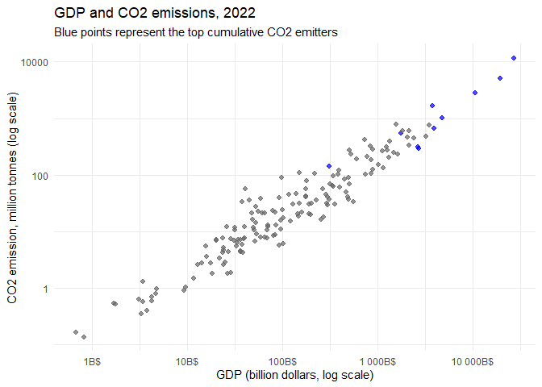

```r
# Visualize with a scatterplot
gdp_countries |>
  ggplot(aes(x = gdp, y = co2,
             color = country %in% top_cumulative$country)) +
  geom_point(alpha = 0.7, size = 1.7) +
  scale_color_manual(
    values = c("FALSE" = "grey40", "TRUE" = "blue"),
    breaks = "TRUE",
    name = NULL
  ) +
  scale_x_log10(
    labels = scales::label_number(
      scale = 1e-9,
      suffix = "B$",
      accuracy = 1
    )) +
  scale_y_log10() +
  labs(title = paste("GDP and CO2 emissions,", last_gdp_year),
       subtitle = "Blue points represent the top cumulative CO2 emitters",
       x = "GDP (billion dollars, log scale)",
       y = "CO2 emission, million tonnes (log scale)",
       color = "Top emittor") +
  theme_minimal() +
  theme(legend.position = "none")
```

```r
library(modelr)

# Modelling
model <- lm(log_co2 ~ log_gdp, data = gdp_countries)

model$coefficients
```

```
## (Intercept)     log_gdp
##   -9.807123    1.010025
```

```r
summary(model)$r.squared
```

```
## [1] 0.922202
```

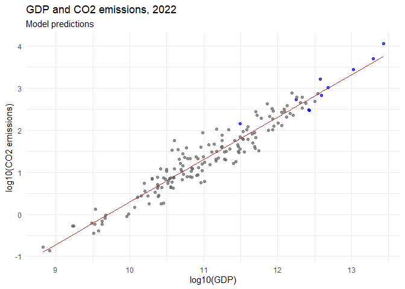

```r
# Visualize the model
grid <- gdp_countries |>
  data_grid(log_gdp) |>
  add_predictions(model)

gdp_countries |>
  ggplot(aes(x = log_gdp, color = country %in% top_cumulative$country)) +
  geom_point(aes(y = log_co2), alpha = 0.7) +
  geom_line(data = grid, aes(y = pred), color = "firebrick") +
  scale_color_manual(
    values = c("FALSE" = "grey40", "TRUE" = "blue"),
    breaks = "TRUE",
    name = NULL
  ) +
  labs(title = paste("GDP and CO2 emissions,", last_gdp_year),
       subtitle = "Model predictions",
       x = "log10(GDP)",
       y = "log10(CO2 emissions)") +
  theme_minimal() +
  theme(legend.position = "none")
```

```r
library(ggrepel)

# Residuals
gdp_countries <- gdp_countries |>
  add_residuals(model)

# Countries emitting much more than expected given their GDP
highest <-
  gdp_countries |> slice_max(resid, n = 5) |> select(country, resid, log_gdp)
highest
```

```
## # A tibble: 5 × 3
##   country             resid log_gdp
##   <chr>               <dbl>   <dbl>
## 1 North Korea         0.844    10.6
## 2 Turkmenistan        0.655    11.0
## 3 Trinidad and Tobago 0.648    10.6
## 4 Mongolia            0.596    10.7
## 5 Venezuela           0.555    11.2
```

```r
# Countries emitting much less than expected given their GDP
lowest <-
  gdp_countries |> slice_min(resid, n = 5) |> select(country, resid, log_gdp)
lowest
```

```
## # A tibble: 5 × 3
##   country                       resid log_gdp
##   <chr>                         <dbl>   <dbl>
## 1 Switzerland                  -0.540    11.7
## 2 Uganda                       -0.523    11.0
## 3 Democratic Republic of Congo -0.504    11.0
## 4 Sri Lanka                    -0.495    11.4
## 5 Ethiopia                     -0.483    11.4
```

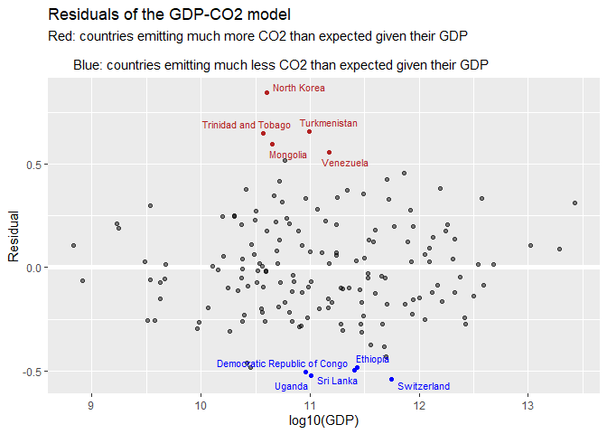

```r
gdp_countries |>
  ggplot(aes(x = log_gdp, y = resid)) +
  geom_ref_line(h = 0) +
  geom_point(alpha = 0.5) +
  geom_point(data = highest, color = "firebrick") +
  geom_text_repel(data = highest, aes(label = country),
            size = 3, color = "firebrick") +
  geom_point(data = lowest, color = "blue") +
  geom_text_repel(data = lowest, aes(label = country),
            size = 3, color = "blue") +
  labs(title = "Residuals of the GDP-CO2 model",
       subtitle =
         "Red: countries emitting much more CO2 than expected given their GDP\n
       Blue: countries emitting much less CO2 than expected given their GDP",
       x = "log10(GDP)", y = "Residual")
```

The scatterplot on logarithmic scales shows a strong, almost linear relationship between a country’s GDP and its CO2 emissions. A linear model on the log-transformed variables confirms it: GDP explains about 92% of the variation in emissions across countries (R² = 0.92), and the slope is close to 1 (1.01). Emissions grow roughly in proportion to GDP, so a country with a GDP ten times larger emits, on average, about ten times more CO2. The largest historical emitters lie close to the regression line, which means their emissions are mostly explained by the size of their economies. The residuals show which countries deviate most from this trend. North Korea, Turkmenistan, Trinidad and Tobago, Mongolia and Venezuela emit three to seven times more than expected, because their economies rely heavily on coal or on oil and gas extraction. Switzerland emits about a third of what its GDP would predict, thanks to a service-based economy and an almost carbon-free electricity supply. Uganda, the Democratic Republic of Congo, Sri Lanka and Ethiopia are also well below the line, largely because much of their energy comes from biomass, which is not included in fossil CO2 emissions. These results describe an association, not a causal effect: both GDP and emissions grow with population, so part of the relationship simply reflects the size of countries.